# Lab4: Testowanie hipotez

Michał Ciach, Anna Macioszek

### Nadobnice alpejskie w Bieszczadach

**Zadanie przykładowe.**. Za pomocą [testu dwumianowego](https://en.wikipedia.org/wiki/Binomial_test) zweryfikuj, czy na podstawie tych danych można stwierdzić, że *R. longicorn* preferencyjnie wybiera składy drewna.

**Rozwiązanie.** Test dwumianowy służy do zweryfikowania hipotezy, że prawdopodobieństwo wystąpienia jakiegoś zdarzenia jest równe $p_0$. Formalnie, rozpatrujemy zmienną losową $Y$ równą $1$ gdy dane zdarzenie wystąpiło i $0$ w przeciwnym przypadku. Nasza hipoteza to
$$H_0 : \mathbb{P}(Y=1) = p_0,$$
hipoteza alternatywna natomiast zależy od danego pytania badawczego. Zajmiemy się nią za chwilę.

Tak jak zawsze przy testowaniu hipotez, zakładamy, że hipoteza $H_0$ jest prawdziwa i przy tym założeniu sprawdzamy, czy możemy w danych zaobserwować coś o podejrzanie małym prawdopodobieństwie. Jeśli tak, to odrzucamy $H_0$ na korzyść $H_1$. W tym przypadku badamy liczbę wystąpień danego zdarzenia, którą oznaczymy jako $X$. Zmienna $Y$ mówi nam, czy zdarzenie wystąpiło w jednym eksperymencie, zmienna $X$ natomiast oznacza liczbę wystąpień zdarzenia w serii eksperymentów statystycznych (na przykład pomiarów).  
Jeśli przeprowadziliśmy $N$ pomiarów, to, przy założeniu $H_0$, zmienna $X$ ma [rozkład dwumianowy](https://en.wikipedia.org/wiki/Binomial_distribution) $Bin(N, p_0)$, skąd pochodzi nazwa testu.

W naszym przypadku będziemy badać, czy na podstawie zebranych danych możemy stwierdzić, że *R. longicorn* wybiera składy drewna z prawdopodobieństwem większym niż $p_0 = 1/2$. Stąd, nasza hipoteza alternatywna to
$$H_1 : \mathbb{P}(Y=1) > 1/2.$$
Jakie zdarzenia mogą świadczyć o tym, że prawdziwa jest raczej $H_1$ niż $H_0$?
Skoro $H_1$ mówi, że *R. longicorn* wybiera składy drewna *częściej* niż wybrane $p_0$, to sprawdzimy, czy zaobserwowana liczba wystąpień w składach drewna, czyli $X$, jest nieprawdopodobnie wysoka.

Nasza liczba przeprowadzonych eksperymentów (pomiarów) to $N=110$, ponieważ tyle historycznych wystąpień zbadał zespół ekologów. Stąd, przy założeniu $H_0$, liczba wystąpień w składach drewna powinna mieć rozkład $Bin(110, 0.5)$.  
Żeby przeprowadzić test dwumianowy musimy jeszcze otrzymać zaobserwowaną wartość zmiennej losowej $X$.  
Skoro *R. longicorn* wystąpiła w składach drewna w 66,7% przypadków, to obliczamy $X = 0.667*110 = 73.37$, co zaokrąglamy do $73$. Tworzymy zmienne w R które przechowają nam te wartości:

```r
N = 110
X = as.integer(110*0.667)
```

*Dygresja dotycząca R.* W powyższym kawałku kodu wykorzystałem znak równości `=` zamiast strzałki w lewo `<-`.  
Obie metody są poprawne i w tym przypadku nie ma między nimi żadnej różnicy.  
Różnica występuje natomiast przy wywoływaniu funkcji. Komenda `ggplot(data=X)` może zadziałać inaczej, niż `ggplot(data <- X)`, i w 99% przypadków należy stosować tę pierwszą.  
Są to szczegóły techniczne i na tym kursie nie musicie się nimi przejmować. Zainteresowani mogą dowiedzieć się więcej [tutaj](https://renkun.me/2014/01/28/difference-between-assignment-operators-in-r/).

Sformułowaliśmy już nasze hipotezy badawcze i otrzymaliśmy wartość naszej *statystyki testowej* $X$.  
Teraz należy sprawdzić, czy $X$ przyjęła nietypowo wysoką wartość.  
W tym celu obliczymy, jakie jest prawdopodobieństwo, że $X$ wyniosłaby *co najmniej* 73 gdyby prawdziwa była $H_0$.  
Takie prawdopodobieństwo nazywamy *p-wartością*. Jeśli to prawdopodobieństwo będzie małe (na ogół przyjmuje się próg 0.05), to odrzucimy hipotezę zerową i uznamy, że składy drewna bukowego rzeczywiście stanowią pułapkę ekologiczną dla *R. longicorn*.

Bardzo ważne jest, aby rozpatrzeć *co najmniej* tak nietypowe wartości, jak te zaobserwowane. To dlatego, że zaobserwowanie *dokładnie* danej, konkretnej liczby na ogół samo w sobie jest bardzo małe.  
Z tego powodu obliczenie $\mathbb{P}(X=73)$ niewiele by nam powiedziało o tym, czy $X$ jest nietypowo wysoka.

Do obliczenia p-wartości $\mathbb{P}(X \geq 73)$ wykorzystamy funkcję `pbinom`.  
Dokumentację, jak zawsze, możecie przeczytać wpisując w konsolę komendę `?pbinom`. Tutaj jednak czai się kolejna pułapka: funkcja `pbinom(73)` zwróci nam wartość $\mathbb{P}(X \leq 73)$. Nas natomiast interesuje $\mathbb{P}(X \geq 73) = 1 - \mathbb{P}(X < 73) = 1 - \mathbb{P}(X \leq 72)$.  
Z tego powodu w poniższym kawałku kodu musimy odjąć 1 od wartości zmiennej $X$.

```r
p.value = 1 - pbinom(X - 1, N, 0.5) # = P(X >= successes)
p.value
```

```
## [1] 0.0003844925
```

Widzimy, że prawdopodobieństwo zaobserwowania co najmniej 73 wystąpień w składach drewna jest szalenie małe.  
Gdyby $H_0$ była prawdziwa, to takie zjawisko wystąpiłoby raz na $1/0.00038 \approx 2600$ powtórzeń takiego eksperymentu.  
Na tej podstawie stwierdzamy, że *R. longicorn* preferencyjnie osiedla się w składach drewna.

Całą procedurę możemy dodatkowo zilustrować na wykresie, na którym zaznaczymy typowe i nietypowe wartości zmiennej $X$.  
W pierwszym kroku należy utworzyć ramkę danych z której stworzymy wykres.  
Po pierwsze, potrzebujemy wektora wartości jakie może przyjąć zmiena $X$, czyli wektora `1:N`. Następnie, obliczymy prawdopodobieństwo przyjęcia każdej z tych wartości komendą `dbinom(1:N, N, 0.5)`.  
Na końcu policzymy wektor p-wartości odpowiadających każdej z potencjalnych wartości zmiennej $X$, `1 - pbinom(1:N - 1, N, 0.5)`, i stworzymy wektor logiczny mówiący nam, czy p-wartość jest większa niż 0.05, komendą `1 - pbinom(1:N - 1, N, 0.5) >= 0.05`.  
Otrzymane wektory ustawimy w ramkę danych:

```r
data.to.plot <- data.frame('X' = 1:N, 'dbinom' = dbinom(1:N, N, 0.5), 'Typical' = 1 - pbinom(1:N - 1, N, 0.5) >= 0.05)
```

Otrzymaną ramkę danych możemy wykorzystać do stworzenia następującego wykresu (po załadowaniu biblioteki `ggplot2`):

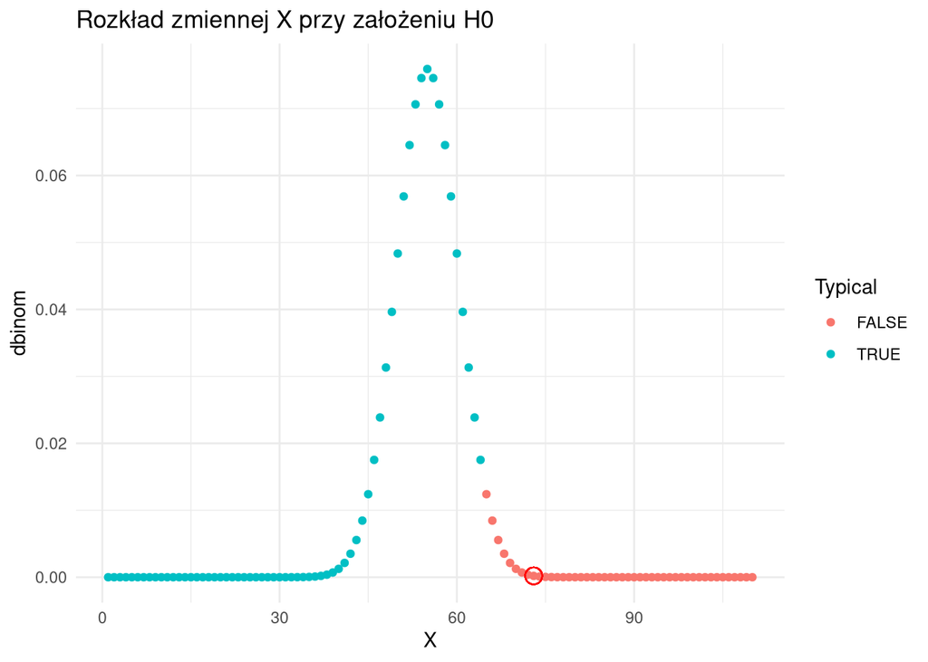

```r
ggplot(data.to.plot) + geom_point(aes(x=X, y=dbinom, col=Typical)) + ggtitle('Rozkład zmiennej X przy założeniu H0') + theme_minimal() + geom_point(aes(x = 73, y = dbinom(73, N, 0.5)), col=I('red'), shape=1, size=4)
```

**Zadanie 1.** Dane zebrane przez zespół wskazują, że przed rokiem 2000 *R. longicorn* zamieszkujące składy drewna stanowiły 0.40 wszystkich wystąpień tego owada. Po 2000 liczba ta wzrosła do 0.76.  
Za pomocą testu niezależności chi-kwadrat zweryfikuj, czy wybór siedliska zależy od okresu.  
Oblicz p-wartość korzystając z funkcji `pchisq`, a następnie zweryfikuj swoje wyniki za pomocą `chisq.test`.

Test niezależności chi-kwadrat był omówiony na Wykładzie 3. Więcej informacji na jego temat możesz znaleźć również [tutaj](https://stattrek.com/chi-square-test/independence.aspx).

**Wskazówka.** Aby przeprowadzić test niezależności chi-kwadrat, musimy najpierw obliczyć *tabelę kontyngencji*, podsumowującą liczby wystąpień *R. longicorn* w różnych siedliskach w zależności od okresu:

| Liczba wystąpień | Przed 2000 r. | Po 2000 r. |
| --- | --- | --- |
| Skład drewna | $O_{11}$ | $O_{12}$ |
| Siedlisko naturalne | $O_{21}$ | $O_{22}$ |

Z poprzedniego zadania wiemy, że zbadano $N=110$ wystąpień owada, a 66.7% spośród nich było w składzie drewna. Żeby uzupełnić tabelę kontyngencji musimy jeszcze obliczyć procent owadów znalezionych przed rokiem 2000.

Oznaczmy przez $A$ zdarzenie polegające na tym, że losowo wybrany owad zamieszkuje skład drewna, a przez $B$ zdarzenie, że losowo wybrana obserwacja jest sprzed roku 2000. Zdarzenie przeciwne oznaczmy przez $B'$.
Korzystając ze *wzoru na prawdopodobieństwo całkowite* możemy teraz napisać
$$\mathbb{P}(A) = \mathbb{P}(A
| B) \mathbb{P}(B) + \mathbb{P}(A | B') \mathbb{P}(B') =
\mathbb{P}(A | B) \mathbb{P}(B) + \mathbb{P}(A | B') (1 -
\mathbb{P}(B)).$$
Zwróćmy uwagę, że z treści zadania znamy zarówno $\mathbb{P}(A | B)$, jak i $\mathbb{P}(A | B')$ – jest to odpowiednio 0.40 i 0.76. Mamy zatem
$$0.667
= 0.40 \mathbb{P}(B) + 0.76 (1 - \mathbb{P}(B)),$$
a po przekształceniu tej równości otrzymujemy $\mathbb{P}(B) = (0.667 - 0.76)/(0.4 - 0.76) \approx 0.26$.

W tabeli kontyngencji oznaczyliśmy $O_{11}$ jako liczbę owadów znalezionych w składzie drewna przed rokiem 2000.
Obliczymy tę wartość jako $N\mathbb{P}(A \wedge B)$. Prawdopodobieństwo zajścia obu zdarzeń naraz, $\mathbb{P}(A \wedge B)$, obliczymy korzystając z *reguły łańcuchowej* jako
$$\mathbb{P}(A \wedge B) = \mathbb{P}(A | B)
\mathbb{P}(B) = 0.40 \cdot 0.26 = 0.1033.$$
Wobec tego na podstawie danych z zadania mamy $O_{11} = 110*0.1033 = 11.36$, co zaokrąglamy do 11.

Pozostałe elementy macierzy kontyngencji należy obliczyć analogicznie. Statystyka testowa i jej rozkład pod warunkiem $H_0$ podane są na slajdach z wykładu oraz na podlinkowanej wcześniej stronie. Aby wykorzystać funkcję `chisq.test`, należy utworzyć tabelę kontyngencji korzystając z funkcji `matrix` omówionej na poprzednich zajęciach. **Koniec wskazówki.**

Uwaga, opcja `correct=T` zwróci inny wynik niż obliczony ręcznie.

### Zadłużenie gmin c.d.

W następnym zadaniu wykorzystamy test t Studenta aby porównać średnie zadłużenia gmin z wybranych województw.

**Zadanie 2.** *Przygotowanie danych.*  
Zaczniemy od wczytania danych znajdujące się w pliku `Zadluzenie gmin.csv`, dostępnym na stronie przedmiotu.  
Ogólny sposób wczytywania danych został opisany na poprzednich zajęciach.  
W tym zadaniu jednak czai się na nas kolejna pułapka.  
Druga kolumna danych zawiera *kod terytorialny* gminy, którego pierwsze dwie cyfty to identyfikator województwa. Część kodów terytorialnych zaczyna się od zera. R domyślnie uzna, że ta kolumna zawiera liczby, więc te zera usunie.  
Żeby je zachować, musimy ręcznie podać typy danych w kolejnych kolumnach za pomocą argumentu `colClasses`:

```r
Zadluzenie.gmin <- read.delim("Zadluzenie gmin.csv", colClasses = c('factor', 'factor', 'factor', 'numeric', 'factor', 'factor'))
```

Ponieważ kazaliśmy R-owi interpretować drugą kolumnę jako factor, to zachowa on początkowe zera z kodów terytorialnych. W następnym kroku dodamy do naszych danych kolumnę zawierającą nazwy województw w których znajdują się gminy. Na początku musimy wybrać dwa pierwsze znaki z każdego identyfikatora.  
Do obsługi napisów w R najlepiej nadaje się biblioteka `stringr`. Zainstaluj ją komendą `install.packages("stringr")`, a następnie załaduj i wykorzystaj funkcję `str_sub()`, aby otrzymać wektor zawierający po dwa pierwsze znaki z każdego identyfikatora terytorialnego. Dołącz ten wektor do danych `Zadluzenie.gmin` jako nową kolumnę. Sposób dołączania kolumn do ramki danych był omówiony na pierwszych zajęciach.

Następnym krokiem będzie przetłumaczenie otrzymanego wektora na nazwy województw.  
Poniższa komórka z kodem utworzy wektor, którego pola nazwane są identyfikatorem województw, a zawierają ich nazwy.

```r
slownik <- c('02' = 'Dolnośląskie', '04' = 'Kujawsko-pomorskie',
             '06' = 'Lubelskie', '08' = 'Lubuskie',
             '10' = 'Łódzkie', '12' = 'Małopolskie',
             '14' = 'Mazowieckie', '16' = 'Opolskie',
             '18' = 'Podkarpackie', '20' = 'Podlaskie',
             '22' = 'Pomorskie', '24' = 'Śląskie',
             '26' = 'Świętokrzyskie', '28' = 'Warmińsko-mazurskie',
             '30' = 'Wielkopolskie',  '32' = 'Zachodniopomorskie')
```

Jedną z opcji indeksowania wektorów w R jest indeksowanie po nazwach pól.  
Dzięki temu stworzony powyżej wektor umożliwia nam bardzo proste przetłumaczenie pierwszych dwóch znaków kodu terytorialnego na nazwę województwa.  
Wystarczy napisać `slownik[c('02', '02', '04')]`, aby automatycznie przetłumaczyć wektor `c('02', '02', '04')` na wektor `c("Dolnośląskie", "Dolnośląskie", "Kujawsko-pomorskie")`.

Wykorzystaj zmienną `slownik`, aby utworzyć w danych `Zadluzenie.gmin` nową kolumnę zawierającą nazwy województw.

Tak jak na poprzednich zajęciach, jeśli uważasz, że w danych występują obserwacje odstające, to usuń je przed dalszą analizą.

**Zadanie 3.** Czy na podstawie danych możemy stwierdzić, że średnie zadłużenie gminy w województwie mazowieckim jest mniejsze niż 25%? Wykorzystaj jednopróbkowy test t Studenta przy hipotezach $H_0: \mu = 25$, $H_1 : \mu < 25$. Oblicz p-wartość samodzielnie, a następnie porównaj swój wynik z funkcją `t.test`. Dystrybuantę rozkładu t Studenta możesz obliczyć korzystając z funkcji `pt`. Pamiętaj, że funkcja `var` wykorzystuje nieobciążony estymator wariancji.

*Wskazówka.* Mając nazwy województw w kolumnie `Wojewodztwo`, dane dotyczące województwa mazowieckiego możesz wybrać komendą `Zadluzenie.gmin[Zadluzenie.gmin$Wojewodztwo == 'Mazowieckie', ]`.

Ponieważ p-wartość jest duża, to nie mamy podstaw żeby uznać że średnie zadłużenie jest mniejsze niż 25%. *Co to oznacza?* W tym zadaniu założyliśmy, że zadłużenie gminy to zmienna losowa o pewnym rozkładzie prawdopodobieństwa, a w danych obserwujemy realizacje tej zmiennej losowej. Po pewnym czasie możemy obliczyć zadłużenie gmin ponownie. Jeśli nasze “warunki eksperymentalne” się nie zmienią, to otrzymamy nowy zestaw realizacji zmiennych losowych z tego samego rozkładu.  
Wynik testu wskazuje, że rozrzut zadłużenia gmin jest na tyle duży, że po wykonaniu pomiaru ponownie średnie zadłużenie może okazać się wyższe lub równe 25%.

Zwróć uwagę, że jest to nieco inna interpretacja niż w przypadku badanych wcześniej chrząszczy. Tam mieliśmy do czynienia z próbą wybraną z pewnej populacji, i zastanawialiśmy się, czy te losowo wybrane chrząszcze pozwalają nam wyciągnąć wnioski na temat całej populacji. To, że wśród 110 zbadanych chrząszczy 66,7% mieszkało w składzie drewna nie musi oznaczać, że dokładnie 66,7% wszystkich chrząszczy z Bieszczad mieszka w składach drewna. Możemy jednak z dużą dozą pewności uznać, że w takich składach żyje więcej niż połowa wszystkich osobników *R. longicorn*.

W tym zadaniu mamy do dyspozycji całą “populację” gmin, więc średnie zadłużenie gmin na Mazowszu w roku 2015 wyniosło po prostu 24,38% i kropka.  
To, co tutaj badamy, to własności ukrytego procesu losowego który wygenerował nam nasze dane. Interesuje nas na przykład to, na ile to zadłużenie może się zmieniać w czasie.  
Takie podejście jest przydatne na przykład w sytuacji, gdy chcemy przekazać środki finansowe z województw o małym zadłużeniu do województw o wysokim zadłużeniu. Chcielibyśmy wówczas być pewni, że wybrane “bogate” województwa rzeczywiście mają wystarczająco małe zadłużenie. Przeprowadzenie testów i skonstruowanie przedziałów ufności w takiej sytuacji pozwala nam w większym stopniu kontrolować naturalną zmienność występującą w naszych danych i zmniejszyć ryzyko związane z podejmowaniem decyzji.

Choć formalizm matematyczny w obu przypadkach jest identyczny, to warto zdawać sobie sprawę z innego znaczenia wykorzystywanych wzorów.

Powyższy wniosek uzasadnia dodatkowo wykorzystanie w następnym zadaniu testu t Studenta dla prób o równych wariancjach.

**Zadanie 5.** Czy na podstawie danych możemy stwierdzić, że przeciętna gmina z Pomorskiego jest zadłużona bardziej niż z Łódzkiego?  
Wykorzystaj test t Studenta dla populacji o różnych licznościach, ale równych wariancjach (Wykład 2).  
Porównaj swoje wyniki z otrzymanymi za pomocą funkcji `t.test`; Zwróć uwagę na parametr `var.equal`.

W tym przypadku p-wartość możemy obliczyć łatwiej, niż w poprzednim zadaniu. Ponieważ interesują nas zarówno nietypowo wysokie jak i niskie wartości statystyki testowej, a rozkład tej ostatniej jest symetryczny względem zera, robimy to następująco:
$$p =
\mathbb{P}(|X| > |x|) = \mathbb{P}(X > |x|) + \mathbb{P}(X <
-|x|) = 2\mathbb{P}(X < -|x|).$$

### Zadania dodatkowe (nieobowiązkowe).

**Zadanie 1.** Wybierz dwa województwa. Zweryfiuj hipotezę o tym, że średnie zadłużenie gmin z tych województw jest równe, za pomocą dwupróbkowego testu t Studenta dla prób o różnych rozmiarach i wariancjach (tzw. [test Welscha](https://en.wikipedia.org/wiki/Welch%27s_t-test)). Hipoteza alternatywna w tym przypadku jest taka, że średnie zadłużenia są różne (tzw. *hipoteza dwustronna*).  
Oblicz p-wartość samodzielnie, korzystając ze wzoru na statystykę testową (mającą rozkład t Studenta) i jej liczbę stopni swobody podaną w podlinkowanym artykule. Porównaj ją z wynikiem funkcji `t.test`.

**Zadanie 2.** Liczba obserwacji w macierzy kontyngencji, którą obliczyliśmy w Zadaniu 1, jest raczej niska.  
To oznacza że test chi-kwadrat może nie być odpowiedni.  
Wykonaj dokładny test Fishera i porównaj wyniki. Po wykonaniu własnego testu, zweryfikuj wyniki za pomocą `fisher.test`.